# Personal Loan Campaign

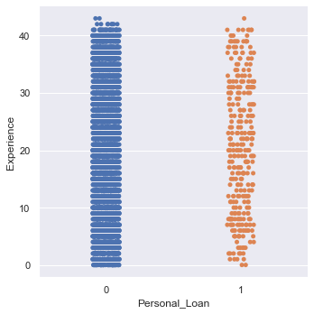

```python
plt.figure(figsize=(5,8))
sns.catplot(x="Personal_Loan", y="Experience", data=df1)
plt.show()
```

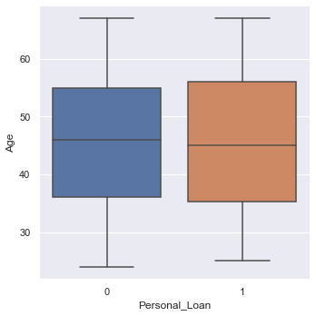

```python
plt.figure(figsize=(10,5))
sns.catplot(x="Personal_Loan", y="Age", kind="box", data=df1)
plt.show()
```

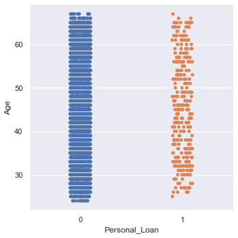

```python
plt.figure(figsize=(10,5))
sns.catplot(x="Personal_Loan", y="Age", data=df1)
plt.show()
```

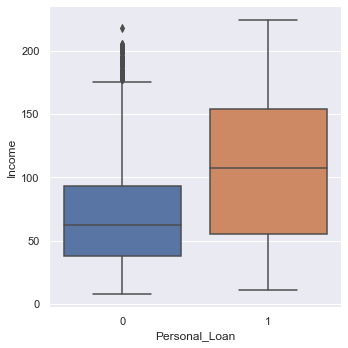

```python
plt.figure(figsize=(10,5))
sns.catplot(x="Personal_Loan", y="Income", kind="box", data=df1)
plt.show()
```

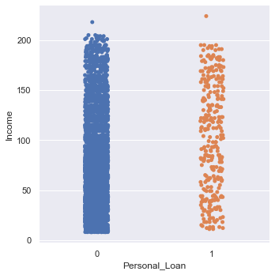

```python
plt.figure(figsize=(10,5))
sns.catplot(x="Personal_Loan", y="Income", data=df1)
plt.show()
```

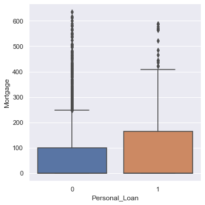

```python
plt.figure(figsize=(10,5))
sns.catplot(x="Personal_Loan", y="Mortgage", kind="box", data=df1)
plt.show()
```

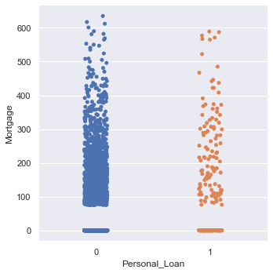

```python
plt.figure(figsize=(10,5))
sns.catplot(x="Personal_Loan", y="Mortgage", data=df1)
plt.show()
```

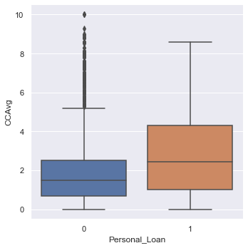

```python
plt.figure(figsize=(10,5))
sns.catplot(x="Personal_Loan", y="CCAvg", kind="box", data=df1)
plt.show()
```

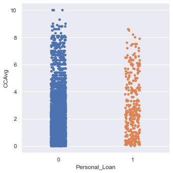

```python
plt.figure(figsize=(10,5))
sns.catplot(x="Personal_Loan", y="CCAvg",data=df1)
plt.show()
```

```python
df1.corr() # there is a very high correlation between age and experience.One of them should be dropped
```

|  | Age | Experience | Income | CCAvg | Mortgage |
| --- | --- | --- | --- | --- | --- |
| Age | 1.000000 | 0.994080 | -0.058466 | -0.050433 | -0.015059 |
| Experience | 0.994080 | 1.000000 | -0.049585 | -0.048399 | -0.013222 |
| Income | -0.058466 | -0.049585 | 1.000000 | 0.645306 | 0.206853 |
| CCAvg | -0.050433 | -0.048399 | 0.645306 | 1.000000 | 0.110224 |
| Mortgage | -0.015059 | -0.013222 | 0.206853 | 0.110224 | 1.000000 |

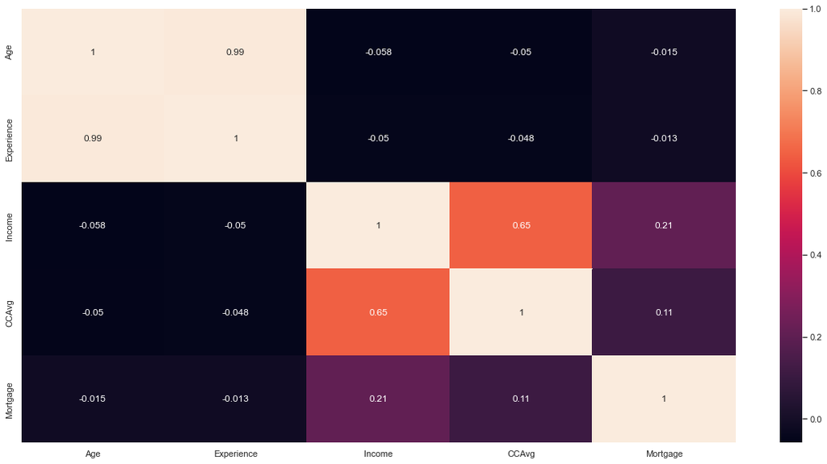

```python
plt.figure(figsize=(20,10))
sns.heatmap(df1.corr(), annot= True)
```

### Observation

1) There is a very high correlation between age and experience; one of them should be dropped. 2) Customers who use internet banking and have a credit card by any other bank can be a possible target for a personal loan. 3) Customers who have high income may get a personal loan 4) Customers who use credit cards may get a personal loan. 5) Customers who are from the superior region may not get a personal loan

```python
df1.drop(["Experience"], axis=1, inplace=True) #drop the experience column
```

```python
quartiles = np.quantile(df1['Mortgage'][df1['Mortgage'].notnull()], [.25, .75]) #check outliers
Mortgage_4iqr = 4 * (quartiles[1] - quartiles[0])
outliers_Mortgage = df1.loc[np.abs(df1['Mortgage'] - df1['Mortgage'].median()) > Mortgage_4iqr, 'Mortgage']
outliers_Mortgage
```

```
42      412
59      455
303     617
354     419
365     466
459     458
473     547
479     470
570     485
684     449
782     587
952     524
1111    442
1167    475
1273    437
```

[output cut: 54 more lines]

```python
df1.drop(outliers_Mortgage.index, axis=0, inplace=True) # drop the outliers
```

```python
quartiles2 = np.quantile(df1['Income'][df1['Income'].notnull()], [.25, .75])
Income_4iqr = 4 * (quartiles[1] - quartiles[0])
outliers_Income = df1.loc[np.abs(df1['Income'] - df1['Income'].median()) > Income_4iqr, 'Income']
outliers_Income #no outlier
```

```
Series([], Name: Income, dtype: int64)
```

```python
quartiles3 = np.quantile(df1['CCAvg'][df1['CCAvg'].notnull()], [.25, .75])
CCAvg_4iqr = 4 * (quartiles[1] - quartiles[0])
outliers_CCAvg = df1.loc[np.abs(df1['CCAvg'] - df1['CCAvg'].median()) > CCAvg_4iqr, 'CCAvg']
outliers_CCAvg #no outliers
```

```
Series([], Name: CCAvg, dtype: float64)
```

```python
df1.dtypes
```

```
Age                      int64
Income                   int64
Family                category
CCAvg                  float64
Education             category
Mortgage                 int64
Personal_Loan         category
Securities_Account    category
CD_Account            category
Online                category
CreditCard            category
Region                  object
dtype: object
```

```python
dummy_df = pd.get_dummies(df1, columns=["Education", "Region","Family"], drop_first=True) # get dummy only for education and county variables because the other categorical variables have only two values (1 and 0)
dummy_df.head()
```

|  | Age | Income | CCAvg | Mortgage | Personal_Loan | Securities_Account | CD_Account | Online | CreditCard | Education_2 | Education_3 | Region_CENTRAL | Region_LOS ANGELES | Region_SOUTHERN | Region_SUPERIOR | Family_2 | Family_3 | Family_4 |
| --- | --- | --- | --- | --- | --- | --- | --- | --- | --- | --- | --- | --- | --- | --- | --- | --- | --- | --- |
| 0 | 25 | 49 | 1.6 | 0 | 0 | 0 | 1 | 0 | 0 | 0 | 0 | 0 | 1 | 0 | 0 | 0 | 0 | 1 |
| 1 | 45 | 34 | 1.5 | 0 | 0 | 0 | 1 | 0 | 0 | 0 | 0 | 0 | 1 | 0 | 0 | 0 | 1 | 0 |
| 2 | 39 | 11 | 1.0 | 0 | 0 | 0 | 0 | 0 | 0 | 0 | 0 | 0 | 0 | 0 | 0 | 0 | 0 | 0 |
| 3 | 35 | 100 | 2.7 | 0 | 0 | 0 | 0 | 0 | 0 | 1 | 0 | 0 | 0 | 0 | 0 | 0 | 0 | 0 |
| 4 | 35 | 45 | 1.0 | 0 | 0 | 0 | 0 | 0 | 1 | 1 | 0 | 0 | 1 | 0 | 0 | 0 | 0 | 1 |

```python
X = dummy_df.drop(["Personal_Loan"], axis=1)
y = dummy_df["Personal_Loan"].astype("int") #target variable
```

```python
X_train, X_test, y_train, y_test = train_test_split(X, y, test_size=0.3, random_state=1)
```

```python
X_train.shape
```

```
(3392, 17)
```

```python
X_test.shape
```

```
(1455, 17)
```

```python
print("training set:")
print(y_train.value_counts(normalize=True))
print("testing set:")
print(y_test.value_counts(normalize=True))
```

```
training set:
0    0.941038
1    0.058962
Name: Personal_Loan, dtype: float64
testing set:
0    0.940206
1    0.059794
Name: Personal_Loan, dtype: float64
```

# Logistic Regression

```python
model = LogisticRegression(solver="newton-cg", random_state=1)
log_reg = model.fit(X_train, y_train)
```

```python
df_coef = pd.DataFrame(
    np.append(log_reg.coef_, log_reg.intercept_),
    index=X_train.columns.tolist() + ["Intercept"],
    columns=["Coefficients"],
)
df_coef.T
```

|  | Age | Income | CCAvg | Mortgage | Securities_Account | CD_Account | Online | CreditCard | Education_2 | Education_3 | Region_CENTRAL | Region_LOS ANGELES | Region_SOUTHERN | Region_SUPERIOR | Family_2 | Family_3 | Family_4 | Intercept |
| --- | --- | --- | --- | --- | --- | --- | --- | --- | --- | --- | --- | --- | --- | --- | --- | --- | --- | --- |
| Coefficients | -0.007186 | -0.001456 | 0.15448 | 0.002311 | 4.065555 | 4.438846 | 4.052482 | 4.287789 | -0.13644 | -0.404805 | -0.018781 | -0.026815 | -0.209249 | -0.121993 | -0.38833 | -0.078955 | -0.304657 | -10.222928 |

```python
odds = np.exp(log_reg.coef_[0]) # convert coefficients to odds
perc_change_odds = (np.exp(log_reg.coef_[0]) - 1) * 100 # find the percentage change
pd.DataFrame({"Odds": odds, "Change_odd%": perc_change_odds}, index=X_train.columns).T
```

|  | Age | Income | CCAvg | Mortgage | Securities_Account | CD_Account | Online | CreditCard | Education_2 | Education_3 | Region_CENTRAL | Region_LOS ANGELES | Region_SOUTHERN | Region_SUPERIOR | Family_2 | Family_3 | Family_4 |
| --- | --- | --- | --- | --- | --- | --- | --- | --- | --- | --- | --- | --- | --- | --- | --- | --- | --- |
| Odds | 0.99284 | 0.998545 | 1.167051 | 1.002314 | 58.297283 | 84.677131 | 57.540066 | 72.805341 | 0.872458 | 0.667107 | 0.981394 | 0.973542 | 0.811193 | 0.885155 | 0.678188 | 0.924081 | 0.737377 |
| Change_odd% | -0.71599 | -0.145489 | 16.705111 | 0.231416 | 5729.728266 | 8367.713069 | 5654.006585 | 7180.534138 | -12.754159 | -33.289279 | -1.860558 | -2.645821 | -18.880651 | -11.484508 | -32.181160 | -7.591867 | -26.262346 |

#### Observation

1) Age, income, Education 2 and 3, Region (central, Los Angles, southern, and superior) are negative; an increase in these will decrease the chances of a customer being a personal loan user. 2) Security account, CD account, online banking, credit card, CCAVG, and mortgage are positive; an increase in these will increase the chances of a customer being a personal loan user. 3) A unit change in Age will decrease the odds of a customer being a personal loan user by 0.99 times or a 0.71 % decrease in the odds. 4) A unit change in Family 4 will decrease the odds of a customer being a personal loan user by 0.73 times or a 26.26 % decrease. 5) A unit change in the southern region will decrease the odds of a customer being a personal loan user by 0.81 times or an 18.88 % decrease. 6) A unit change in the education-3 will decrease the odds of a customer being a personal loan user by 0.66 times or a 33.28 % decrease. 7) A unit change in CD account will increase the odds of a customer being a personal loan user by 84.67 times increase. 8) A unit change in security account will increase the odds of a customer being a personal loan user by a 58.29 times increase. 9) A unit change in online will increase the odds of a customer being a personal loan user by a 57.54 times increase. 10) A unit change in the mortgage will increase the odds of a customer being a personal loan user by a 1 time increase.

```python
def log_reg_model_performance_with_threshold(model, predictors, target, threshold):
    pred_prob = model.predict_proba(predictors)[:, 1]
    pred_thres = pred_prob > threshold
    prediction = np.round(pred_thres)

    accuracy = accuracy_score(target, prediction)
    recall = recall_score(target, prediction)
    precision = precision_score(target, prediction)
    f1 = f1_score(target, prediction)
    df_perf_log = pd.DataFrame(
        {
            "Accuracy": accuracy,
            "Recall": recall,
            "Precision": precision,
            "F1": f1,
        },
        index=[0],
    )

    return df_perf_log
```

```python
print("Training performance:")
log_reg_model_performance_with_threshold_05_train=log_reg_model_performance_with_threshold(log_reg,X_train, y_train,threshold=0.5)
log_reg_model_performance_with_threshold_05_train
```

```
Training performance:
```

|  | Accuracy | Recall | Precision | F1 |
| --- | --- | --- | --- | --- |
| 0 | 0.979658 | 0.655 | 1.0 | 0.791541 |

```python
print("Testing performance:")
log_reg_model_performance_with_threshold_05_test=log_reg_model_performance_with_threshold(log_reg,X_test,y_test,threshold=0.5)
log_reg_model_performance_with_threshold_05_test
```

```
Testing performance:
```

|  | Accuracy | Recall | Precision | F1 |
| --- | --- | --- | --- | --- |
| 0 | 0.976632 | 0.609195 | 1.0 | 0.757143 |

```python
def log_reg_confusion_matrix_with_threshold(model, predictors, target, threshold):
    pred_prob = model.predict_proba(predictors)[:, 1]
    pred_thres = pred_prob > threshold
    y_prediction = np.round(pred_thres)

    cm = confusion_matrix(target, y_prediction)
    labels = np.asarray(
        [
            ["{0:0.0f}".format(item) + "\n{0:.2%}".format(item / cm.flatten().sum())]
            for item in cm.flatten()
        ]
    ).reshape(2, 2)

    plt.figure(figsize=(10, 4))
    sns.heatmap(cm, annot=labels, fmt="")
    plt.ylabel("True")
    plt.xlabel("Predicted")
```

```
confusion matrix
```

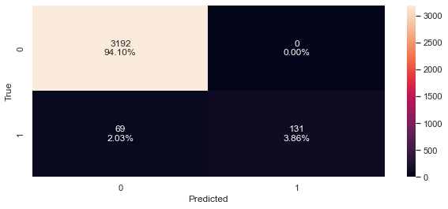

```python
print("confusion matrix")
log_reg_confusion_matrix_with_threshold(log_reg, X_train, y_train, threshold=0.5)
```

```python
threshold_curve1 = 0.1
```

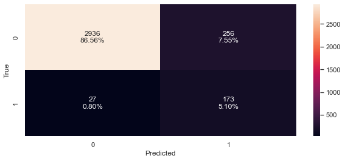

```python
log_reg_confusion_matrix_with_threshold(log_reg, X_train, y_train, threshold=threshold_curve1)
```

```python
print("Training performance:")
log_reg_model_performance_with_threshold_01_train=log_reg_model_performance_with_threshold(log_reg,X_train, y_train, threshold=threshold_curve1)
log_reg_model_performance_with_threshold_01_train
```

```
Training performance:
```

|  | Accuracy | Recall | Precision | F1 |
| --- | --- | --- | --- | --- |
| 0 | 0.916568 | 0.865 | 0.403263 | 0.550079 |

```python
print("Testing performance:")
log_reg_model_performance_with_threshold_01_test=log_reg_model_performance_with_threshold(log_reg,X_test,y_test,threshold=threshold_curve1)
log_reg_model_performance_with_threshold_01_test
```

```
Testing performance:
```

|  | Accuracy | Recall | Precision | F1 |
| --- | --- | --- | --- | --- |
| 0 | 0.905155 | 0.747126 | 0.359116 | 0.485075 |

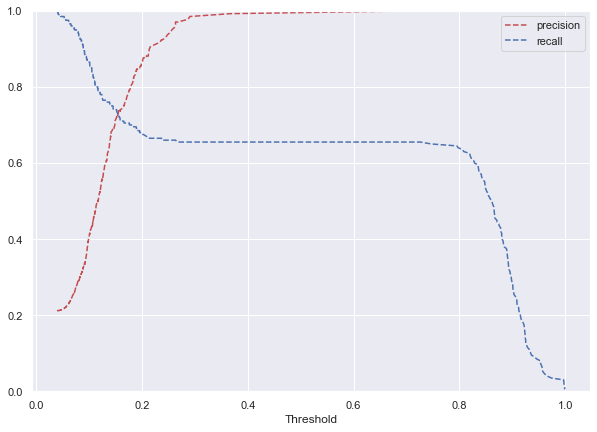

```python
y_sco = log_reg.predict_proba(X_train)[:, 1] # Use Precision-Recall curve to find a better threshold
precision, recall, thresholds = precision_recall_curve(y_train, y_sco)


def plot_prec_recall_vs_tresh(precisions, recalls, thresholds):
    plt.plot(thresholds, precisions[:-1], "r--", label="precision")
    plt.plot(thresholds, recalls[:-1], "b--", label="recall")
    plt.xlabel("Threshold")
    plt.legend(loc="upper right")
    plt.ylim([0, 1])


plt.figure(figsize=(10, 7))
plot_prec_recall_vs_tresh(precision, recall, thresholds)
plt.show()
```

```python
threshold_curve2 = 0.16
```

```python
print("Training performance:")
log_reg_model_performance_with_threshold_016_train=log_reg_model_performance_with_threshold(log_reg,X_train, y_train, threshold=threshold_curve2)
log_reg_model_performance_with_threshold_016_train
```

```
Training performance:
```

|  | Accuracy | Recall | Precision | F1 |
| --- | --- | --- | --- | --- |
| 0 | 0.968455 | 0.71 | 0.743455 | 0.726343 |

```python
print("Testing performance:")
log_reg_model_performance_with_threshold_016_test=log_reg_model_performance_with_threshold(log_reg,X_test,y_test,threshold=threshold_curve2)
log_reg_model_performance_with_threshold_016_test
```

```
Testing performance:
```

|  | Accuracy | Recall | Precision | F1 |
| --- | --- | --- | --- | --- |
| 0 | 0.964948 | 0.62069 | 0.75 | 0.679245 |

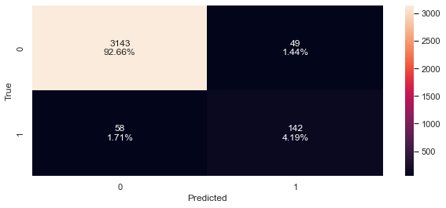

```python
log_reg_confusion_matrix_with_threshold(log_reg, X_train, y_train, threshold=threshold_curve2)
```

```python
log_reg_model_performance_with_threshold_05_train = log_reg_model_performance_with_threshold_05_train.rename(index={0:"threshold_05_train"})
```

```python
log_reg_model_performance_with_threshold_05_train.index.name=None
log_reg_model_performance_with_threshold_05_train
```

|  | Accuracy | Recall | Precision | F1 |
| --- | --- | --- | --- | --- |
| threshold_05_train | 0.979658 | 0.655 | 1.0 | 0.791541 |

```python
log_reg_model_performance_with_threshold_01_train = log_reg_model_performance_with_threshold_01_train.rename(index={0:"threshold_01_train"})
log_reg_model_performance_with_threshold_01_train
```

|  | Accuracy | Recall | Precision | F1 |
| --- | --- | --- | --- | --- |
| threshold_01_train | 0.916568 | 0.865 | 0.403263 | 0.550079 |

```python
log_reg_model_performance_with_threshold_016_train = log_reg_model_performance_with_threshold_016_train.rename(index={0:"threshold_016_train"})
log_reg_model_performance_with_threshold_016_train
```

|  | Accuracy | Recall | Precision | F1 |
| --- | --- | --- | --- | --- |
| threshold_016_train | 0.968455 | 0.71 | 0.743455 | 0.726343 |

```python
log_reg_model_performance_with_threshold_01_test = log_reg_model_performance_with_threshold_01_test.rename(index={0:"threshold_01_test"})
log_reg_model_performance_with_threshold_01_test
```

|  | Accuracy | Recall | Precision | F1 |
| --- | --- | --- | --- | --- |
| threshold_01_test | 0.905155 | 0.747126 | 0.359116 | 0.485075 |

```python
log_reg_model_performance_with_threshold_016_test = log_reg_model_performance_with_threshold_016_test.rename(index={0:"threshold_016_test"})
log_reg_model_performance_with_threshold_016_test
```

|  | Accuracy | Recall | Precision | F1 |
| --- | --- | --- | --- | --- |
| threshold_016_test | 0.964948 | 0.62069 | 0.75 | 0.679245 |

```python
log_reg_model_performance_with_threshold_05_test = log_reg_model_performance_with_threshold_05_test.rename(index={0:"threshold_05_test"})
log_reg_model_performance_with_threshold_05_test
```

|  | Accuracy | Recall | Precision | F1 |
| --- | --- | --- | --- | --- |
| threshold_05_test | 0.976632 | 0.609195 | 1.0 | 0.757143 |

#### Model Performance Comparison

```python
log_reg_perf_train=pd.concat([log_reg_model_performance_with_threshold_05_train,log_reg_model_performance_with_threshold_016_train,log_reg_model_performance_with_threshold_01_train])
```

```python
log_reg_perf_train
```

|  | Accuracy | Recall | Precision | F1 |
| --- | --- | --- | --- | --- |
| threshold_05_train | 0.979658 | 0.655 | 1.000000 | 0.791541 |
| threshold_016_train | 0.968455 | 0.710 | 0.743455 | 0.726343 |
| threshold_01_train | 0.916568 | 0.865 | 0.403263 | 0.550079 |

```python
log_reg_perf_test=pd.concat([log_reg_model_performance_with_threshold_05_test,log_reg_model_performance_with_threshold_016_test,log_reg_model_performance_with_threshold_01_test])
log_reg_perf_test
```

|  | Accuracy | Recall | Precision | F1 |
| --- | --- | --- | --- | --- |
| threshold_05_test | 0.976632 | 0.609195 | 1.000000 | 0.757143 |
| threshold_016_test | 0.964948 | 0.620690 | 0.750000 | 0.679245 |
| threshold_01_test | 0.905155 | 0.747126 | 0.359116 | 0.485075 |

### Observation

1) From the logistic regression model, Security account, CD account, online banking, credit card, CCAVG, and mortgage are significant variables of a customer being a personal loan user. 2) The accuracy scores of the training and test sets are high (more than 0.9) for all thresholds (0.5,0.16, and 0.1), but we should look at the recall score because if it increases, the number of false negatives will decrease, so the model performance increase. 3) The model achieved a recall of 0.86 on the training set and 0.74 test set with the threshold set at 0.1.

# Decision Tree

```python
tree_model = DecisionTreeClassifier(criterion="gini",class_weight={0: 0.94, 1: 0.06}, random_state=1)
tree_model.fit(X_train, y_train)
```

```
DecisionTreeClassifier(class_weight={0: 0.94, 1: 0.06}, random_state=1)
```

```python
def tree_model_performance(model, predictors, target):
    prediction = model.predict(predictors)

    accuracy = accuracy_score(target, prediction)
    recall = recall_score(target, prediction)
    precision = precision_score(target, prediction)
    f1 = f1_score(target, prediction)

    # creating a dataframe of metrics
    df_perf_tree = pd.DataFrame(
        {"Accuracy": accuracy, "Recall": recall, "Precision": precision, "F1": f1,},
        index=[0],
    )

    return df_perf_tree
```

```python
def confusion_matrix_tree(model, predictors, target):
    y_prediction = model.predict(predictors)
    cm = confusion_matrix(target, y_prediction)
    labels = np.asarray(
        [
            ["{0:0.0f}".format(item) + "\n{0:.2%}".format(item / cm.flatten().sum())]
            for item in cm.flatten()
        ]
    ).reshape(2, 2)

    plt.figure(figsize=(6, 4))
    sns.heatmap(cm, annot=labels, fmt="")
    plt.ylabel("True")
    plt.xlabel("Predicted")
```

```python
feature_names = list(X.columns)
print(feature_names)
```

```
['Age', 'Income', 'CCAvg', 'Mortgage', 'Securities_Account', 'CD_Account', 'Online', 'CreditCard', 'Education_2', 'Education_3', 'Region_CENTRAL', 'Region_LOS ANGELES', 'Region_SOUTHERN', 'Region_SUPERIOR', 'Family_2', 'Family_3', 'Family_4']
```

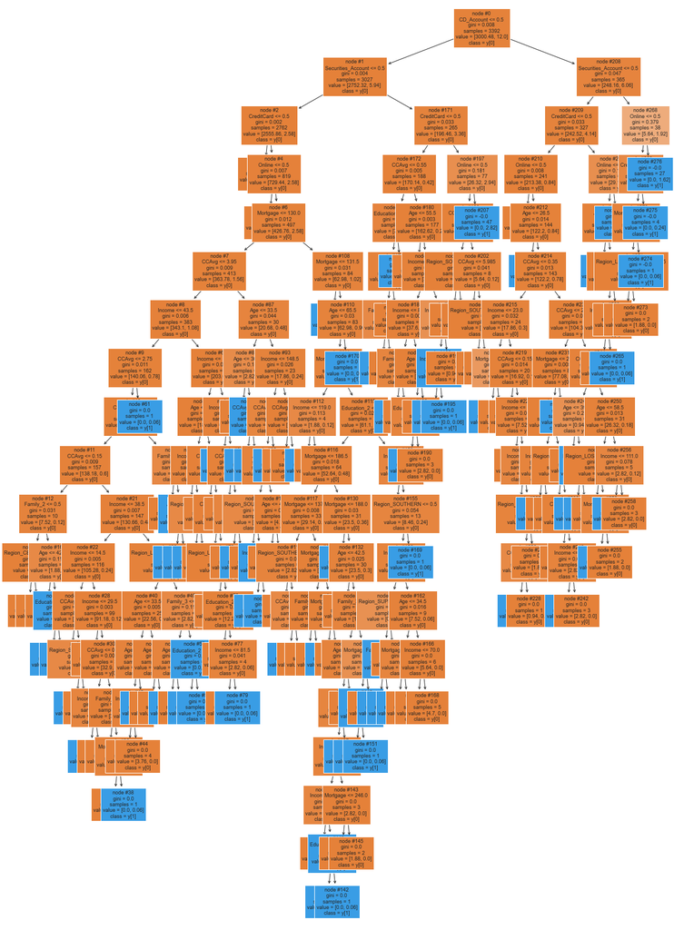

```python
plt.figure(figsize=(20, 30))

tree.plot_tree(
    tree_model,
    feature_names=feature_names,
    filled=True,
    fontsize=9,
    node_ids=True,
    class_names=True,
)
plt.show()
```

```python
print(tree.export_text(tree_model, feature_names=feature_names, show_weights=True))
```

```
|--- CD_Account <= 0.50
|   |--- Securities_Account <= 0.50
|   |   |--- CreditCard <= 0.50
|   |   |   |--- weights: [1826.42, 0.00] class: 0
|   |   |--- CreditCard >  0.50
|   |   |   |--- Online <= 0.50
|   |   |   |   |--- weights: [302.68, 0.00] class: 0
|   |   |   |--- Online >  0.50
|   |   |   |   |--- Mortgage <= 130.00
|   |   |   |   |   |--- CCAvg <= 3.95
|   |   |   |   |   |   |--- Income <= 43.50
|   |   |   |   |   |   |   |--- CCAvg <= 2.75
|   |   |   |   |   |   |   |   |--- CCAvg <= 2.05
|   |   |   |   |   |   |   |   |   |--- CCAvg <= 0.15
|   |   |   |   |   |   |   |   |   |   |--- Family_2 <= 0.50
|   |   |   |   |   |   |   |   |   |   |   |--- truncated branch of depth 2
|   |   |   |   |   |   |   |   |   |   |--- Family_2 >  0.50
|   |   |   |   |   |   |   |   |   |   |   |--- truncated branch of depth 3
|   |   |   |   |   |   |   |   |   |--- CCAvg >  0.15
|   |   |   |   |   |   |   |   |   |   |--- Income <= 38.50
|   |   |   |   |   |   |   |   |   |   |   |--- truncated branch of depth 6
|   |   |   |   |   |   |   |   |   |   |--- Income >  38.50
|   |   |   |   |   |   |   |   |   |   |   |--- truncated branch of depth 5
|   |   |   |   |   |   |   |   |--- CCAvg >  2.05
|   |   |   |   |   |   |   |   |   |--- Family_2 <= 0.50
|   |   |   |   |   |   |   |   |   |   |--- weights: [1.88, 0.00] class: 0
|   |   |   |   |   |   |   |   |   |--- Family_2 >  0.50
|   |   |   |   |   |   |   |   |   |   |--- Age <= 47.00
|   |   |   |   |   |   |   |   |   |   |   |--- weights: [0.00, 0.06] class: 1
|   |   |   |   |   |   |   |   |   |   |--- Age >  47.00
|   |   |   |   |   |   |   |   |   |   |   |--- weights: [0.00, 0.06] class: 1
|   |   |   |   |   |   |   |--- CCAvg >  2.75
|   |   |   |   |   |   |   |   |--- weights: [0.00, 0.06] class: 1
|   |   |   |   |   |   |--- Income >  43.50
|   |   |   |   |   |   |   |--- Income <= 138.50
|   |   |   |   |   |   |   |   |--- Age <= 26.50
|   |   |   |   |   |   |   |   |   |--- Income <= 57.00
|   |   |   |   |   |   |   |   |   |   |--- weights: [2.82, 0.00] class: 0
|   |   |   |   |   |   |   |   |   |--- Income >  57.00
|   |   |   |   |   |   |   |   |   |   |--- Region_CENTRAL <= 0.50
```

[output cut: 222 more lines]

```
|   |   |   |   |--- weights: [0.00, 3.18] class: 1
|   |--- Securities_Account >  0.50
|   |   |--- Online <= 0.50
|   |   |   |--- CreditCard <= 0.50
|   |   |   |   |--- Mortgage <= 167.00
|   |   |   |   |   |--- Region_LOS ANGELES <= 0.50
|   |   |   |   |   |   |--- weights: [3.76, 0.00] class: 0
|   |   |   |   |   |--- Region_LOS ANGELES >  0.50
|   |   |   |   |   |   |--- weights: [1.88, 0.00] class: 0
|   |   |   |   |--- Mortgage >  167.00
|   |   |   |   |   |--- weights: [0.00, 0.06] class: 1
|   |   |   |--- CreditCard >  0.50
|   |   |   |   |--- weights: [0.00, 0.24] class: 1
|   |   |--- Online >  0.50
|   |   |   |--- weights: [0.00, 1.62] class: 1
```

```python
print (pd.DataFrame(tree_model.feature_importances_, columns = ["Importance"], index = X_train.columns).sort_values(by = 'Importance', ascending = False))
```

```
                      Importance
Online              5.460349e-01
Income              8.208461e-02
Age                 7.422798e-02
Mortgage            6.212960e-02
CreditCard          6.203188e-02
CCAvg               4.268161e-02
Securities_Account  3.839950e-02
Region_SOUTHERN     2.404824e-02
Family_2            1.481619e-02
Family_3            1.473148e-02
Education_2         1.020761e-02
CD_Account          9.157044e-03
Region_SUPERIOR     8.903391e-03
Education_3         4.915414e-03
Region_CENTRAL      4.741305e-03
Region_LOS ANGELES  8.892823e-04
Family_4            8.917306e-18
```

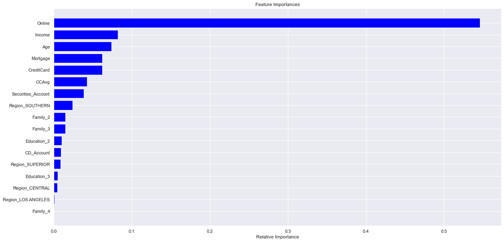

```python
importances = tree_model.feature_importances_
indices = np.argsort(importances)

plt.figure(figsize=(20, 10))
plt.title("Feature Importances")
plt.barh(range(len(indices)), importances[indices], color="blue", align="center")
plt.yticks(range(len(indices)), [feature_names[i] for i in indices])
plt.xlabel("Relative Importance")
plt.show()
```

```python
decision_tree_perf_train = tree_model_performance(tree_model, X_train, y_train)
decision_tree_perf_train
```

|  | Accuracy | Recall | Precision | F1 |
| --- | --- | --- | --- | --- |
| 0 | 1.0 | 1.0 | 1.0 | 1.0 |

```python
decision_tree_perf_test = tree_model_performance(tree_model, X_test, y_test) # model is not giving good results on test set
decision_tree_perf_test
```

|  | Accuracy | Recall | Precision | F1 |
| --- | --- | --- | --- | --- |
| 0 | 0.947079 | 0.62069 | 0.55102 | 0.583784 |

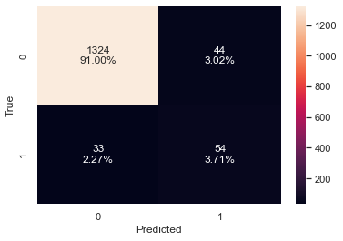

```python
confusion_matrix_tree(tree_model, X_test, y_test)
```

#### Observation

Online, Income, and Age are the top 3 important features for predicting the personal loan buyer. Model training set recall score is 1, but test recall score is 0.62. The model is overfitting and should be improved.

#### Use GridSearch for Hyperparameter to improve model

```python
estimator = DecisionTreeClassifier(random_state=1, class_weight={0: 0.94, 1: 0.06})

# Grid of parameters to choose from

parameters = {
    "max_depth": [5,10,15],
    "criterion": ["entropy", "gini"],
    "splitter": ["best", "random"],
    "min_impurity_decrease": [0.000001, 0.00001, 0.0001],
}

accuracy_scorer = make_scorer(recall_score)

grid_obj = GridSearchCV(estimator, parameters, scoring=accuracy_scorer, cv=5)
grid_obj = grid_obj.fit(X_train, y_train)

estimator = grid_obj.best_estimator_

estimator.fit(X_train, y_train)
```

```
DecisionTreeClassifier(class_weight={0: 0.94, 1: 0.06}, criterion='entropy',
                       max_depth=15, min_impurity_decrease=1e-06,
                       random_state=1)
```

```python
decision_tree_grid_perf_train = tree_model_performance(estimator, X_train, y_train)
decision_tree_grid_perf_train
```

|  | Accuracy | Recall | Precision | F1 |
| --- | --- | --- | --- | --- |
| 0 | 0.995873 | 0.93 | 1.0 | 0.963731 |

```python
decision_tree_grid_perf_test = tree_model_performance(estimator, X_test, y_test)

decision_tree_grid_perf_test
```

|  | Accuracy | Recall | Precision | F1 |
| --- | --- | --- | --- | --- |
| 0 | 0.957388 | 0.62069 | 0.650602 | 0.635294 |

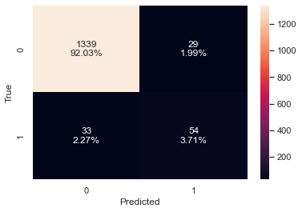

```python
confusion_matrix_tree(estimator, X_test, y_test)
```

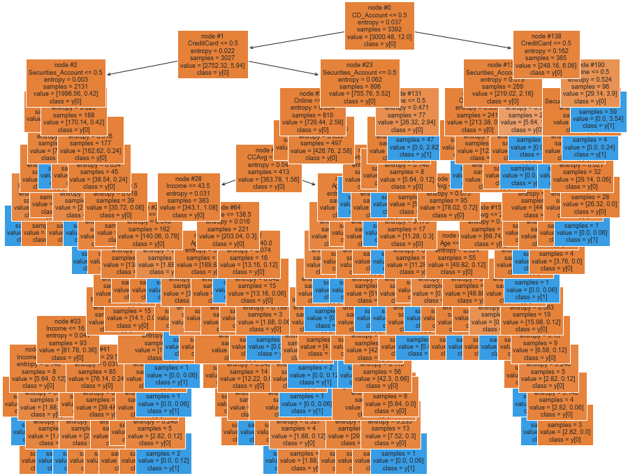

```python
plt.figure(figsize=(15, 12))

tree.plot_tree(
    estimator,
    feature_names=feature_names,
    filled=True,
    fontsize=9,
    node_ids=True,
    class_names=True,
)
plt.show()
```

```python
print(tree.export_text(estimator, feature_names=feature_names, show_weights=True))
```

```
|--- CD_Account <= 0.50
|   |--- CreditCard <= 0.50
|   |   |--- Securities_Account <= 0.50
|   |   |   |--- weights: [1826.42, 0.00] class: 0
|   |   |--- Securities_Account >  0.50
|   |   |   |--- CCAvg <= 0.55
|   |   |   |   |--- Education_2 <= 0.50
|   |   |   |   |   |--- Age <= 34.00
|   |   |   |   |   |   |--- Family_3 <= 0.50
|   |   |   |   |   |   |   |--- weights: [0.00, 0.06] class: 1
|   |   |   |   |   |   |--- Family_3 >  0.50
|   |   |   |   |   |   |   |--- weights: [0.94, 0.00] class: 0
|   |   |   |   |   |--- Age >  34.00
|   |   |   |   |   |   |--- weights: [6.58, 0.00] class: 0
|   |   |   |   |--- Education_2 >  0.50
|   |   |   |   |   |--- weights: [0.00, 0.12] class: 1
|   |   |   |--- CCAvg >  0.55
|   |   |   |   |--- Age <= 55.50
|   |   |   |   |   |--- weights: [124.08, 0.00] class: 0
|   |   |   |   |--- Age >  55.50
|   |   |   |   |   |--- Age <= 56.50
|   |   |   |   |   |   |--- Income <= 152.00
|   |   |   |   |   |   |   |--- weights: [2.82, 0.00] class: 0
|   |   |   |   |   |   |--- Income >  152.00
|   |   |   |   |   |   |   |--- weights: [0.00, 0.18] class: 1
|   |   |   |   |   |--- Age >  56.50
|   |   |   |   |   |   |--- Income <= 89.50
|   |   |   |   |   |   |   |--- Family_2 <= 0.50
|   |   |   |   |   |   |   |   |--- weights: [0.00, 0.06] class: 1
|   |   |   |   |   |   |   |--- Family_2 >  0.50
|   |   |   |   |   |   |   |   |--- weights: [1.88, 0.00] class: 0
|   |   |   |   |   |   |--- Income >  89.50
|   |   |   |   |   |   |   |--- weights: [33.84, 0.00] class: 0
|   |--- CreditCard >  0.50
|   |   |--- Securities_Account <= 0.50
|   |   |   |--- Online <= 0.50
|   |   |   |   |--- weights: [302.68, 0.00] class: 0
|   |   |   |--- Online >  0.50
|   |   |   |   |--- Mortgage <= 130.00
|   |   |   |   |   |--- CCAvg <= 3.95
```

[output cut: 165 more lines]

```
|   |   |   |--- Securities_Account <= 0.50
|   |   |   |   |--- Age <= 29.00
|   |   |   |   |   |--- weights: [0.00, 0.06] class: 1
|   |   |   |   |--- Age >  29.00
|   |   |   |   |   |--- Age <= 34.50
|   |   |   |   |   |   |--- Family_2 <= 0.50
|   |   |   |   |   |   |   |--- weights: [2.82, 0.00] class: 0
|   |   |   |   |   |   |--- Family_2 >  0.50
|   |   |   |   |   |   |   |--- weights: [0.00, 0.06] class: 1
|   |   |   |   |   |--- Age >  34.50
|   |   |   |   |   |   |--- weights: [26.32, 0.00] class: 0
|   |   |   |--- Securities_Account >  0.50
|   |   |   |   |--- weights: [0.00, 0.24] class: 1
|   |   |--- Online >  0.50
|   |   |   |--- weights: [0.00, 3.54] class: 1
```

```python
print (pd.DataFrame(estimator.feature_importances_, columns = ["Importance"], index = X_train.columns).sort_values(by = 'Importance', ascending = False))
```

```
                    Importance
Online                0.319848
Securities_Account    0.154768
CreditCard            0.137909
CD_Account            0.097683
Income                0.089318
CCAvg                 0.068934
Age                   0.057797
Mortgage              0.028998
Family_2              0.021645
Education_2           0.010696
Region_LOS ANGELES    0.004542
Family_3              0.003061
Region_SOUTHERN       0.002813
Region_CENTRAL        0.001988
Region_SUPERIOR       0.000000
Education_3           0.000000
Family_4              0.000000
```

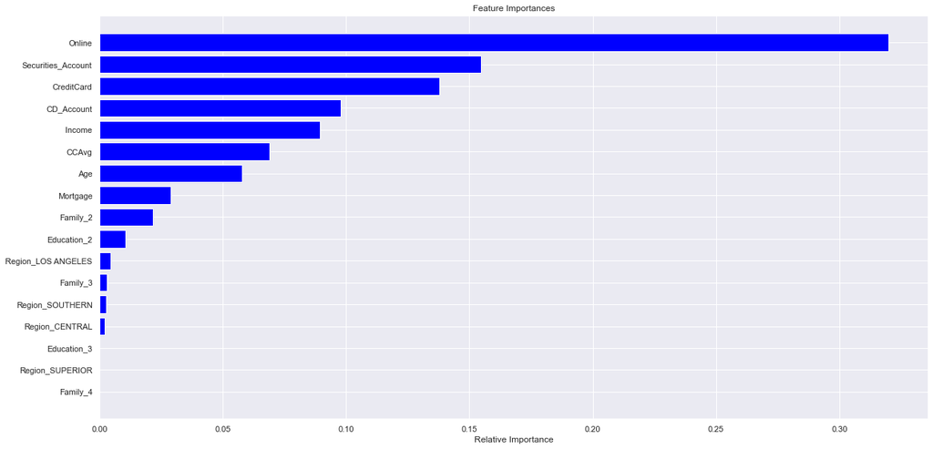

```python
importances = estimator.feature_importances_
indices = np.argsort(importances)

plt.figure(figsize=(20, 10))
plt.title("Feature Importances")
plt.barh(range(len(indices)), importances[indices], color="blue", align="center")
plt.yticks(range(len(indices)), [feature_names[i] for i in indices])
plt.xlabel("Relative Importance")
plt.show()
```

#### Observation

Online, security account, and credit card are the top 3 important features for predicting the personal loan buyer. Model training set recall score is 0.93, but test score is 0.62. The model is overfitting and should be improved.

# Cost Complexity Pruning

```python
ccp_tree = DecisionTreeClassifier(random_state=1, class_weight={0: 0.94, 1: 0.06})
path = ccp_tree.cost_complexity_pruning_path(X_train, y_train)
ccp_alphas, impurities = path.ccp_alphas, path.impurities
```

```python
pd.DataFrame(path)
```

|  | ccp_alphas | impurities |
| --- | --- | --- |
| 0 | 0.000000e+00 | -2.907790e-17 |
| 1 | 7.075991e-20 | -2.900714e-17 |
| 2 | 7.075991e-20 | -2.893638e-17 |
| 3 | 7.075991e-20 | -2.886562e-17 |
| 4 | 7.075991e-20 | -2.879486e-17 |
| 5 | 7.075991e-20 | -2.872410e-17 |
| 6 | 7.075991e-20 | -2.865334e-17 |
| 7 | 7.075991e-20 | -2.858258e-17 |
| 8 | 7.075991e-20 | -2.851182e-17 |
| 9 | 7.075991e-20 | -2.844106e-17 |
| 10 | 1.415198e-19 | -2.829954e-17 |
| 11 | 5.196431e-19 | -2.777990e-17 |
| 12 | 6.235717e-19 | -2.715633e-17 |
| 13 | 6.235717e-19 | -2.653276e-17 |
| 14 | 6.235717e-19 | -2.590918e-17 |
| 15 | 6.235717e-19 | -2.528561e-17 |
| 16 | 6.235717e-19 | -2.466204e-17 |
| 17 | 6.928575e-19 | -2.396918e-17 |
| 18 | 1.247143e-18 | -2.272204e-17 |
| 19 | 1.974644e-18 | -2.074740e-17 |
| 20 | 3.048573e-18 | -1.769882e-17 |
| 21 | 3.291073e-18 | -1.440775e-17 |
| 22 | 1.326082e-05 | 3.978247e-05 |
| 23 | 1.326738e-05 | 7.958460e-05 |
| 24 | 1.582151e-05 | 1.586921e-04 |
| 25 | 1.586837e-05 | 2.380340e-04 |
| 26 | 1.591277e-05 | 3.175978e-04 |
| 27 | 1.592144e-05 | 3.972051e-04 |
| 28 | 1.975949e-05 | 4.367240e-04 |
| 29 | 1.975949e-05 | 4.762430e-04 |
| 30 | 1.982675e-05 | 5.158965e-04 |
| 31 | 1.985378e-05 | 5.953116e-04 |
| 32 | 1.986431e-05 | 6.350403e-04 |
| 33 | 1.986642e-05 | 6.747731e-04 |
| 34 | 1.987131e-05 | 7.145157e-04 |
| 35 | 1.987622e-05 | 7.542682e-04 |
| 36 | 1.991720e-05 | 7.941026e-04 |
| 37 | 2.627254e-05 | 1.030555e-03 |
| 38 | 2.647030e-05 | 1.109966e-03 |
| 39 | 2.656241e-05 | 1.189654e-03 |
| 40 | 2.827390e-05 | 1.387571e-03 |
| 41 | 2.981725e-05 | 1.506840e-03 |
| 42 | 3.120092e-05 | 1.662844e-03 |
| 43 | 3.246438e-05 | 2.019953e-03 |
| 44 | 3.464725e-05 | 2.505014e-03 |
| 45 | 3.941498e-05 | 2.544429e-03 |
| 46 | 3.958941e-05 | 2.584019e-03 |
| 47 | 3.965350e-05 | 2.663326e-03 |
| 48 | 3.976603e-05 | 2.742858e-03 |
| 49 | 1.496973e-04 | 2.892555e-03 |
| 50 | 6.221648e-04 | 4.759049e-03 |
| 51 | 6.352146e-04 | 7.935122e-03 |

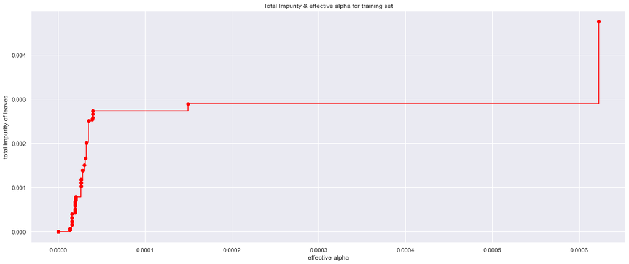

```python
fig, ax = plt.subplots(figsize=(20, 8))
ax.plot(ccp_alphas[:-1], impurities[:-1], marker="o", drawstyle="steps-post", color="red")
ax.set_xlabel("effective alpha")
ax.set_ylabel("total impurity of leaves")
ax.set_title("Total Impurity & effective alpha for training set")
plt.show()
```

```python
clfs = []
for ccp_alpha in ccp_alphas:
    clf = DecisionTreeClassifier(
        random_state=1, ccp_alpha=ccp_alpha, class_weight={0: 0.94, 1: 0.06}
    )
    clf.fit(X_train, y_train)
    clfs.append(clf)
print(
    "Number of nodes in the last tree is: {} with ccp_alpha: {}".format(
        clfs[-1].tree_.node_count, ccp_alphas[-1]))
```

```
Number of nodes in the last tree is: 1 with ccp_alpha: 0.0006352146132104364
```

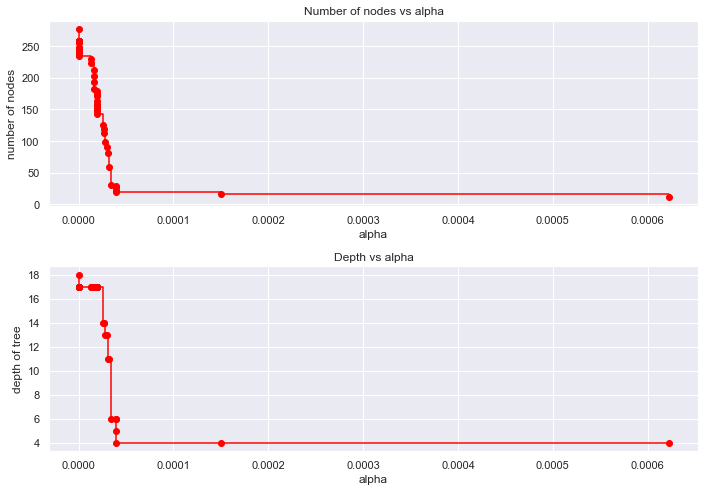

```python
clfs = clfs[:-1]
ccp_alphas = ccp_alphas[:-1]

node_counts = [clf.tree_.node_count for clf in clfs]
depth = [clf.tree_.max_depth for clf in clfs]
fig, ax = plt.subplots(2, 1, figsize=(10, 7))
ax[0].plot(ccp_alphas, node_counts, marker="o", drawstyle="steps-post", color="red")
ax[0].set_xlabel("alpha")
ax[0].set_ylabel("number of nodes")
ax[0].set_title("Number of nodes vs alpha")
ax[1].plot(ccp_alphas, depth, marker="o", drawstyle="steps-post", color="red")
ax[1].set_xlabel("alpha")
ax[1].set_ylabel("depth of tree")
ax[1].set_title("Depth vs alpha")
fig.tight_layout()
```

```python
recall_train = []
for clf in clfs:
    predic_train = clf.predict(X_train)
    values_train = recall_score(y_train, predic_train)
    recall_train.append(values_train)
```

```python
recall_test = []
for clf in clfs:
    predic_test = clf.predict(X_test)
    values_test = recall_score(y_test, predic_test)
    recall_test.append(values_test)
```

```python
train_scores = [clf.score(X_train, y_train) for clf in clfs]
test_scores = [clf.score(X_test, y_test) for clf in clfs]
```

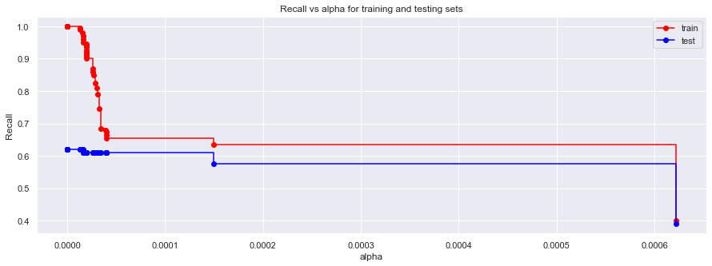

```python
fig, ax = plt.subplots(figsize=(15, 5))
ax.set_xlabel("alpha")
ax.set_ylabel("Recall")
ax.set_title("Recall vs alpha for training and testing sets")
ax.plot(
    ccp_alphas, recall_train, marker="o", label="train", drawstyle="steps-post", color="red")
ax.plot(ccp_alphas, recall_test, marker="o", label="test", drawstyle="steps-post", color="blue")
ax.legend()
plt.show()
```

```python
index_best_model_tree = np.argmax(recall_test)
best_model_tree = clfs[index_best_model_tree]
print(best_model_tree)
```

```
DecisionTreeClassifier(class_weight={0: 0.94, 1: 0.06}, random_state=1)
```

```python
best_model_tree.fit(X_train, y_train)
```

```
DecisionTreeClassifier(class_weight={0: 0.94, 1: 0.06}, random_state=1)
```

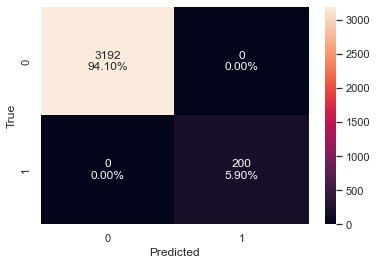

```python
confusion_matrix_tree(best_model_tree, X_train, y_train) # good fit training
```

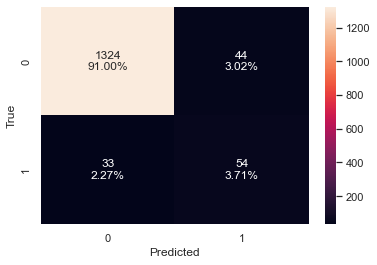

```python
confusion_matrix_tree(best_model_tree, X_test, y_test) # 33 (2.27%) false negative, it is not a good performance for test set
```

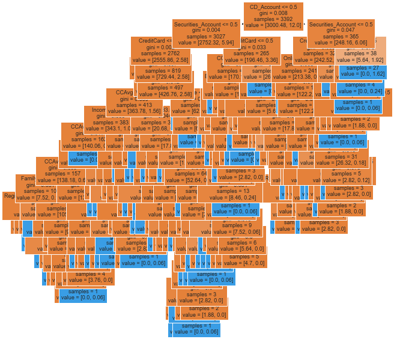

```python
plt.figure(figsize=(10, 10))

out = tree.plot_tree(
    best_model_tree,
    feature_names=feature_names,
    filled=True,
    fontsize=9,
    node_ids=False,
    class_names=None,
)
for o in out:
    arrow = o.arrow_patch
    if arrow is not None:
        arrow.set_edgecolor("black")
        arrow.set_linewidth(1)
plt.show()
```

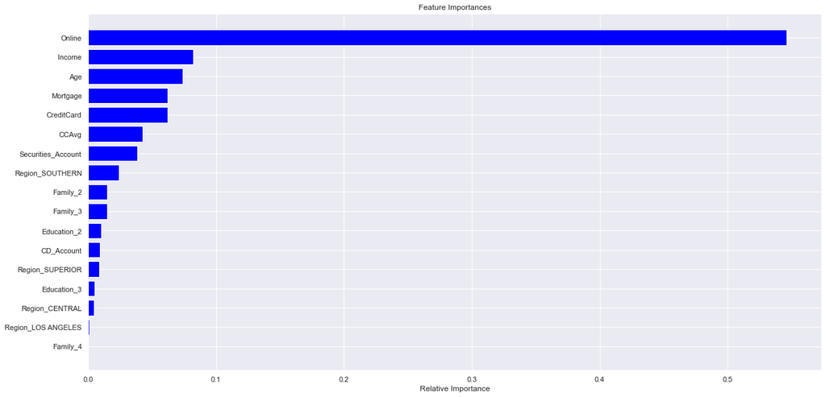

```python
importances = best_model_tree.feature_importances_
indices = np.argsort(importances)

plt.figure(figsize=(20, 10))
plt.title("Feature Importances")
plt.barh(range(len(indices)), importances[indices], color="blue", align="center")
plt.yticks(range(len(indices)), [feature_names[i] for i in indices])
plt.xlabel("Relative Importance")
plt.show()
```

```python
decision_tree_ccp_perf_train = tree_model_performance(best_model_tree, X_train, y_train)

decision_tree_ccp_perf_train
```

|  | Accuracy | Recall | Precision | F1 |
| --- | --- | --- | --- | --- |
| 0 | 1.0 | 1.0 | 1.0 | 1.0 |

```python
decision_tree_ccp_perf_test = tree_model_performance(best_model_tree, X_test, y_test)

decision_tree_ccp_perf_test
```

|  | Accuracy | Recall | Precision | F1 |
| --- | --- | --- | --- | --- |
| 0 | 0.947079 | 0.62069 | 0.55102 | 0.583784 |

### Observation

Online, income and age are the top 3 important features for predicting the personal loan buyer. Model training set recall score is 1 , but test score is 0.62. The model is overfitting and should be improved.

#### Comparing the decision tree models

```python
Dtree_model_performance_test = decision_tree_perf_test.rename(index={0:"Dtree"})
Dtree_model_performance_train = decision_tree_perf_train.rename(index={0:"Dtree"})
estimator_model_performance_test = decision_tree_grid_perf_test.rename(index={0:"estimator"})
estimator_model_performance_train = decision_tree_grid_perf_train.rename(index={0:"estimator"})
decision_tree_ccp_perf_train = decision_tree_ccp_perf_train.rename(index={0:"ccp"})
decision_tree_ccp_perf_test = decision_tree_ccp_perf_test.rename(index={0:"ccp"})
```

```python
Dtree_perf_train_comp=pd.concat([Dtree_model_performance_train,estimator_model_performance_train,decision_tree_ccp_perf_train])
Dtree_perf_train_comp
```

|  | Accuracy | Recall | Precision | F1 |
| --- | --- | --- | --- | --- |
| Dtree | 1.000000 | 1.00 | 1.0 | 1.000000 |
| estimator | 0.995873 | 0.93 | 1.0 | 0.963731 |
| ccp | 1.000000 | 1.00 | 1.0 | 1.000000 |

```python
Dtree_perf_test_comp=pd.concat([Dtree_model_performance_test,estimator_model_performance_test,decision_tree_ccp_perf_test])
Dtree_perf_test_comp
```

|  | Accuracy | Recall | Precision | F1 |
| --- | --- | --- | --- | --- |
| Dtree | 0.947079 | 0.62069 | 0.551020 | 0.583784 |
| estimator | 0.957388 | 0.62069 | 0.650602 | 0.635294 |
| ccp | 0.947079 | 0.62069 | 0.551020 | 0.583784 |

# Conclusion

The decision tree models are overfitting, so the logistic regression model with 0.1 threshold performs better on recall score on training and test sets and can be used. Security account, CD account, online banking, credit card, CCAVG, and mortgage are positive, that increase in these will increase the chances of customer being a personal loan buyer. So, the bank should target the customers who have these features. Age, income, Education 2 and 3, Region (central, Los Angles, southern, and superior) are negative; an increase in these will decrease the chances of being a personal loan buyer.